# chapter6.Rmd

Summary plot of the RATSS data

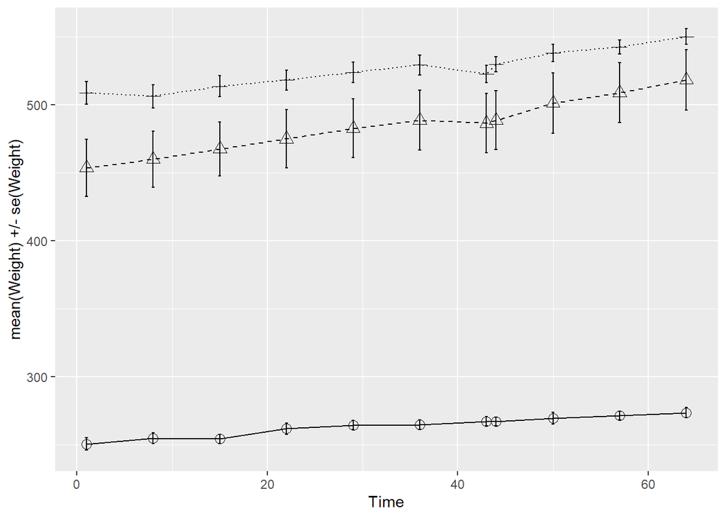

```r
ggplot(RATSS, aes(x = Time, y = mean, linetype = Group, shape = Group)) +
  geom_line() +
  scale_linetype_manual(values = c(1,2,3)) +
  geom_point(size=3) +
  scale_shape_manual(values = c(1,2,3)) +
  geom_errorbar(aes(ymin = mean - se, ymax = mean + se, linetype="1"), width=0.3) +
  theme(legend.position = c(0.8,0.8,0.8)) +
  scale_y_continuous(name = "mean(Weight) +/- se(Weight)")
```

From the plot, it is clear that the average weight of all three groups has increased during the study, but the rate of increase is much slower in group 1 than the other 2 groups and this could be due to the lower baseline weight of this group. Group 3 which has the highest baseline average weight has also the highest final average weight.

Boxplot for the RATSL data

```r
RATSL8S <- RATSL %>%
  filter(Time > 1) %>%
  group_by(Group, ID) %>%
  summarise( mean=mean(Weight) ) %>%
  ungroup()
glimpse(RATSL8S)
```

```
## Observations: 16
## Variables: 3
## $ Group <fct> 1, 1, 1, 1, 1, 1, 1, 1, 2, 2, 2, 2, 3, 3, 3, 3
## $ ID    <fct> 1, 2, 3, 4, 5, 6, 7, 8, 9, 10, 11, 12, 13, 14, 15, 16
## $ mean  <dbl> 263.2, 238.9, 261.7, 267.2, 270.9, 276.2, 274.6, 267.5, ...
```

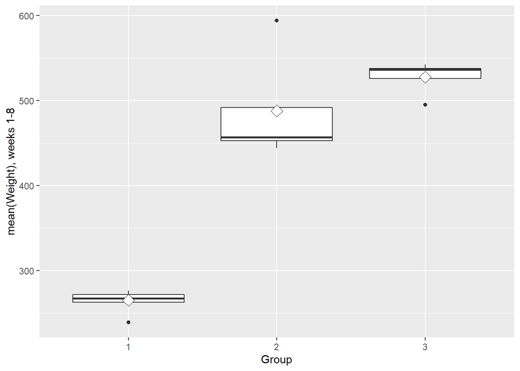

```r
ggplot(RATSL8S, aes(x = Group, y = mean)) +
  geom_boxplot() +
  stat_summary(fun.y = "mean", geom = "point", shape=23, size=4, fill = "white") +
  scale_y_continuous(name = "mean(Weight), weeks 1-8")
```

This boxplot confirms the results of the previous summary plot plus that there is one outlier observation in each group. The outlier of the G2 is above the quartile 3 whereas the outliers of the G1 and G3 are both below the quartile 1.

Filtering the outlier and drawing the plot again

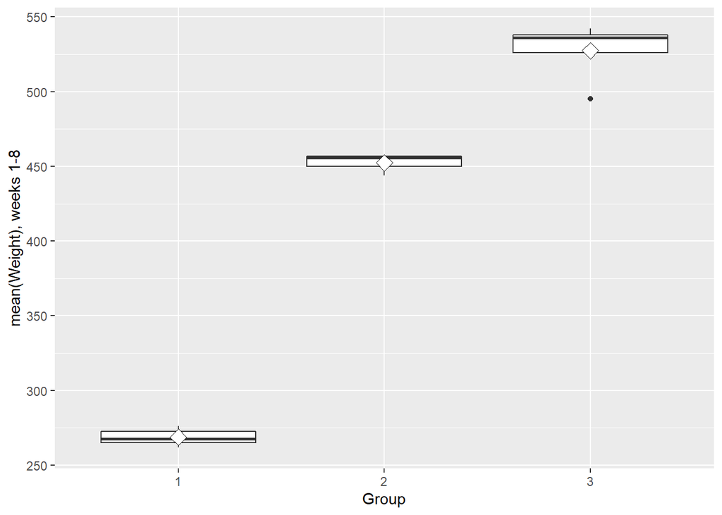

```r
RATSL8S1 <- RATSL8S %>%
  filter(mean < 550)
RATSL8S2 <- RATSL8S1 %>%
  filter(mean > 250)
ggplot(RATSL8S2, aes(x = Group, y = mean)) +
  geom_boxplot() +
  stat_summary(fun.y = "mean", geom = "point", shape=23, size=4, fill = "white") +
  scale_y_continuous(name = "mean(Weight), weeks 1-8")
```

I defined the two ends of the threshold for filtering the outliers from G1 and G2 (mean > 250 & mean < 550), but could not excluded the outlier observation from G3.

ANOVA analysis on RATSL8S2 data

```r
anova <- aov(RATSL8S2$mean ~ RATSL8S2$Group)
summary(anova)
```

```
##                Df Sum Sq Mean Sq F value   Pr(>F)
## RATSL8S2$Group  2 189317   94659   611.4 5.32e-12 ***
## Residuals      11   1703     155
## ---
## Signif. codes:  0 '***' 0.001 '**' 0.01 '*' 0.05 '.' 0.1 ' ' 1
```

Performing Post hoc Tukey test and its plot

```r
tukey <- TukeyHSD(anova)
tukey
```

```
##   Tukey multiple comparisons of means
##     95% family-wise confidence level
##
## Fit: aov(formula = RATSL8S2$mean ~ RATSL8S2$Group)
##
## $`RATSL8S2$Group`
##         diff       lwr      upr    p adj
## 2-1 183.6429 160.45331 206.8324 0.00e+00
## 3-1 258.7429 237.67990 279.8058 0.00e+00
## 3-2  75.1000  49.43387 100.7661 2.01e-05
```

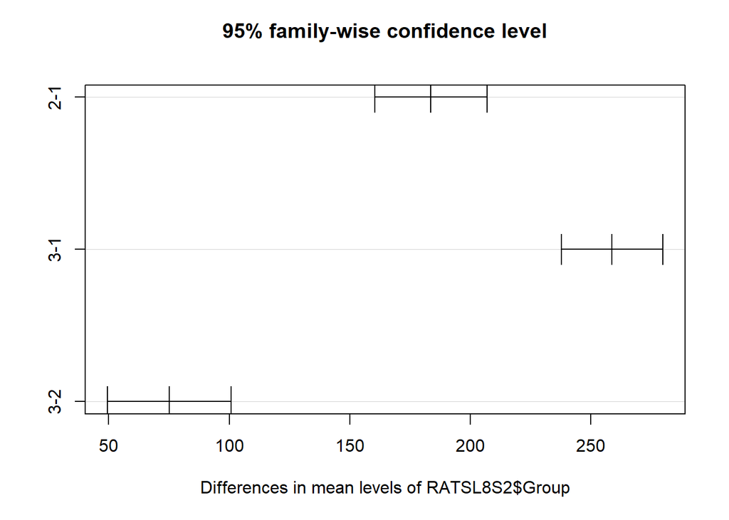

```r
plot(tukey)
```

The output contains the mean difference between each of group pairs, lower end and upper end of the 95% confidence interval and the adjusted p-values. The results of the Tukey test show that all three group pairs are significantly different from each other (G1&G2, G1&G3, G2&G3).

**Analyses of chapter 9 on the BPRS data**

```r
dim(BPRSL)
```

```
## [1] 360   5
```

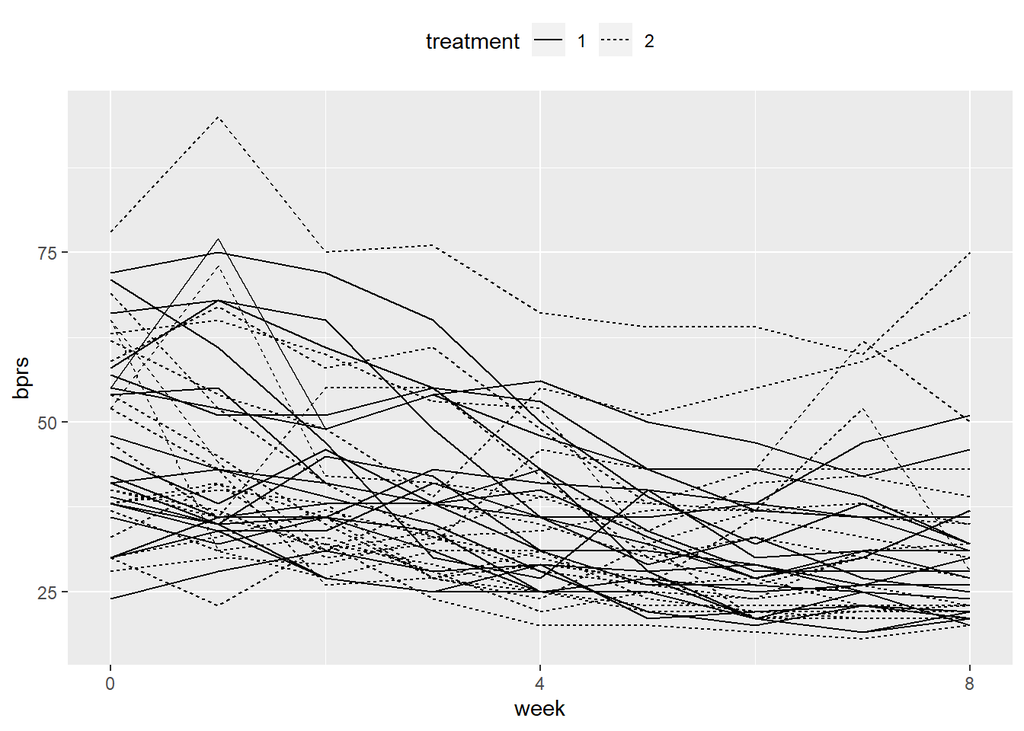

```r
ggplot(BPRSL, aes(x = week, y = bprs, group = interaction(subject, treatment))) +
  geom_line(aes(linetype = treatment)) +
  scale_x_continuous(name = "week", breaks = seq(0, 8, 4)) +
  scale_y_continuous(name = "bprs") +
  theme(legend.position = "top")
```

This plot shows how the bprs scores of the subjects of each treatment group have changed during the 8 weeks of the study.

Fitting a linear model

```r
BPRS_reg <- lm(bprs ~ week + treatment, data = BPRSL)
summary(BPRS_reg)
```

```
##
## Call:
## lm(formula = bprs ~ week + treatment, data = BPRSL)
##
## Residuals:
##     Min      1Q  Median      3Q     Max
## -22.454  -8.965  -3.196   7.002  50.244
##
## Coefficients:
##             Estimate Std. Error t value Pr(>|t|)
## (Intercept)  46.4539     1.3670  33.982   <2e-16 ***
## week         -2.2704     0.2524  -8.995   <2e-16 ***
## treatment2    0.5722     1.3034   0.439    0.661
## ---
## Signif. codes:  0 '***' 0.001 '**' 0.01 '*' 0.05 '.' 0.1 ' ' 1
##
## Residual standard error: 12.37 on 357 degrees of freedom
## Multiple R-squared:  0.1851, Adjusted R-squared:  0.1806
## F-statistic: 40.55 on 2 and 357 DF,  p-value: < 2.2e-16
```

Results of the linear model indicate that treatment 2 is not significantly different from the treatment 1 regarding bprs. Also, it shows that week has a significant main effect on bprs. This model explains about 18% of the variance in bprs.

Random intercept model

```r
library(lme4)
library("lmerTest")
BPRS_ref <- lmer(bprs ~ week + treatment + (1 | subject), data = BPRSL, REML = FALSE)
summary(BPRS_ref)
```

```
## Linear mixed model fit by maximum likelihood . t-tests use
##   Satterthwaite's method [lmerModLmerTest]
## Formula: bprs ~ week + treatment + (1 | subject)
##    Data: BPRSL
##
##      AIC      BIC   logLik deviance df.resid
##   2748.7   2768.1  -1369.4   2738.7      355
##
## Scaled residuals:
##     Min      1Q  Median      3Q     Max
## -3.0481 -0.6749 -0.1361  0.4813  3.4855
##
## Random effects:
##  Groups   Name        Variance Std.Dev.
##  subject  (Intercept)  47.41    6.885
##  Residual             104.21   10.208
## Number of obs: 360, groups:  subject, 20
##
## Fixed effects:
##             Estimate Std. Error       df t value Pr(>|t|)
## (Intercept)  46.4539     1.9090  37.2392  24.334   <2e-16 ***
## week         -2.2704     0.2084 340.0000 -10.896   <2e-16 ***
## treatment2    0.5722     1.0761 340.0000   0.532    0.595
## ---
## Signif. codes:  0 '***' 0.001 '**' 0.01 '*' 0.05 '.' 0.1 ' ' 1
##
## Correlation of Fixed Effects:
##            (Intr) week
## week       -0.437
## treatment2 -0.282  0.000
```

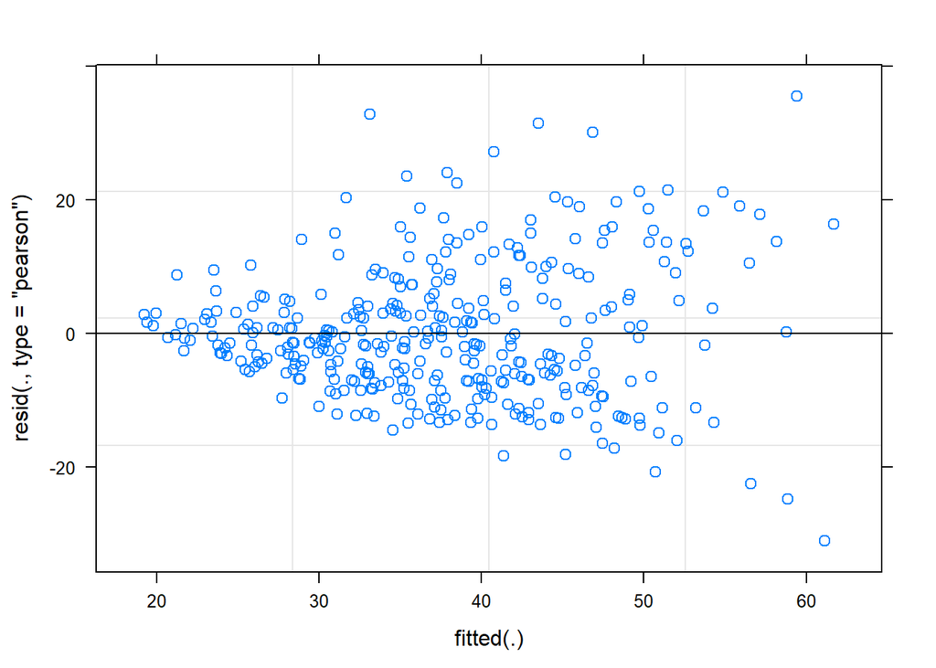

```r
plot(BPRS_ref)
```

```r
anova(BPRS_ref)
```

```
## Type III Analysis of Variance Table with Satterthwaite's method
##            Sum Sq Mean Sq NumDF DenDF  F value Pr(>F)
## week      12371.5 12371.5     1   340 118.7136 <2e-16 ***
## treatment    29.5    29.5     1   340   0.2828 0.5952
## ---
## Signif. codes:  0 '***' 0.001 '**' 0.01 '*' 0.05 '.' 0.1 ' ' 1
```

Fitting a random intercept and random slope model

```r
BPRS_ref1 <- lmer(bprs ~ week + treatment + (week | subject), data = BPRSL, REML = FALSE)
summary(BPRS_ref1)
```

```
## Linear mixed model fit by maximum likelihood . t-tests use
##   Satterthwaite's method [lmerModLmerTest]
## Formula: bprs ~ week + treatment + (week | subject)
##    Data: BPRSL
##
##      AIC      BIC   logLik deviance df.resid
##   2745.4   2772.6  -1365.7   2731.4      353
##
## Scaled residuals:
##     Min      1Q  Median      3Q     Max
## -2.8919 -0.6194 -0.0691  0.5531  3.7977
##
## Random effects:
##  Groups   Name        Variance Std.Dev. Corr
##  subject  (Intercept) 64.8222  8.0512
##           week         0.9609  0.9803   -0.51
##  Residual             97.4304  9.8707
## Number of obs: 360, groups:  subject, 20
##
## Fixed effects:
##             Estimate Std. Error       df t value Pr(>|t|)
## (Intercept)  46.4539     2.1052  22.6796  22.066  < 2e-16 ***
## week         -2.2704     0.2977  19.9985  -7.626 2.42e-07 ***
## treatment2    0.5722     1.0405 320.0007   0.550    0.583
## ---
## Signif. codes:  0 '***' 0.001 '**' 0.01 '*' 0.05 '.' 0.1 ' ' 1
##
## Correlation of Fixed Effects:
##            (Intr) week
## week       -0.582
## treatment2 -0.247  0.000
```

```r
anova(BPRS_ref1, BPRS_ref)
```

```
## Data: BPRSL
## Models:
## BPRS_ref: bprs ~ week + treatment + (1 | subject)
## BPRS_ref1: bprs ~ week + treatment + (week | subject)
##           Df    AIC    BIC  logLik deviance  Chisq Chi Df Pr(>Chisq)
## BPRS_ref   5 2748.7 2768.1 -1369.4   2738.7
## BPRS_ref1  7 2745.4 2772.6 -1365.7   2731.4 7.2721      2    0.02636 *
## ---
## Signif. codes:  0 '***' 0.001 '**' 0.01 '*' 0.05 '.' 0.1 ' ' 1
```

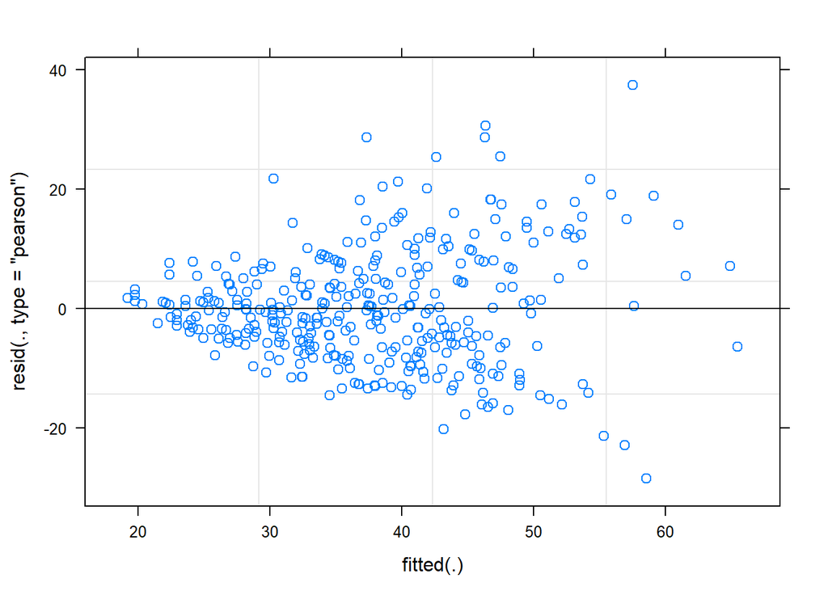

```r
plot(BPRS_ref1)
```

Fitting a random intercept and random slope model with the interaction

```r
BPRS_ref2 <- lmer(bprs ~ week * treatment + (week | subject), data = BPRSL, REML = FALSE)
summary(BPRS_ref2)
```

```
## Linear mixed model fit by maximum likelihood . t-tests use
##   Satterthwaite's method [lmerModLmerTest]
## Formula: bprs ~ week * treatment + (week | subject)
##    Data: BPRSL
##
##      AIC      BIC   logLik deviance df.resid
##   2744.3   2775.4  -1364.1   2728.3      352
##
## Scaled residuals:
##     Min      1Q  Median      3Q     Max
## -3.0512 -0.6271 -0.0768  0.5288  3.9260
##
## Random effects:
##  Groups   Name        Variance Std.Dev. Corr
##  subject  (Intercept) 64.9964  8.0620
##           week         0.9687  0.9842   -0.51
##  Residual             96.4707  9.8220
## Number of obs: 360, groups:  subject, 20
##
## Fixed effects:
##                 Estimate Std. Error       df t value Pr(>|t|)
## (Intercept)      47.8856     2.2521  29.6312  21.262  < 2e-16 ***
## week             -2.6283     0.3589  41.7201  -7.323 5.24e-09 ***
## treatment2       -2.2911     1.9090 319.9977  -1.200   0.2310
## week:treatment2   0.7158     0.4010 319.9977   1.785   0.0752 .
## ---
## Signif. codes:  0 '***' 0.001 '**' 0.01 '*' 0.05 '.' 0.1 ' ' 1
##
## Correlation of Fixed Effects:
##             (Intr) week   trtmn2
## week        -0.650
## treatment2  -0.424  0.469
## wek:trtmnt2  0.356 -0.559 -0.840
```

```r
anova(BPRS_ref2, BPRS_ref1)
```

```
## Data: BPRSL
## Models:
## BPRS_ref1: bprs ~ week + treatment + (week | subject)
## BPRS_ref2: bprs ~ week * treatment + (week | subject)
##           Df    AIC    BIC  logLik deviance  Chisq Chi Df Pr(>Chisq)
## BPRS_ref1  7 2745.4 2772.6 -1365.7   2731.4
## BPRS_ref2  8 2744.3 2775.4 -1364.1   2728.3 3.1712      1    0.07495 .
## ---
## Signif. codes:  0 '***' 0.001 '**' 0.01 '*' 0.05 '.' 0.1 ' ' 1
```

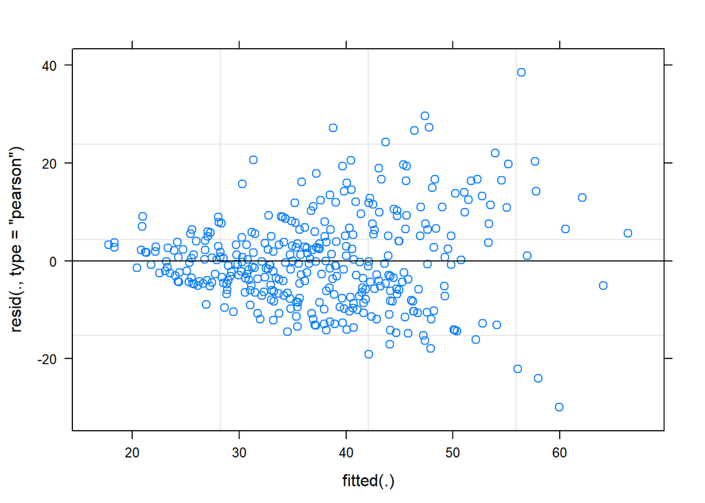

```r
plot(BPRS_ref2)
```

In this model, we also consider the interaction between week and treatment, i.e., to study whether some subjects of a specific treatment group in certain weeks have different bprs profile. From the output we can say that the interaction between week and treatment is not significant (t-value < 2, p-value > 0.05). Also, comparing the chi-squared value and its related p-value we can say that there is no significant difference between this interaction model and the previous random intercept and random slope model and thus the interaction model does not add any new information. As for the previous two models, the fitted vs. residuals plot does not show a certain pattern and the data points are symmetrically dispersed around the y=0 line (linearity of the model) and there is no obvious outlier.

Drawing the plot of BPRSL

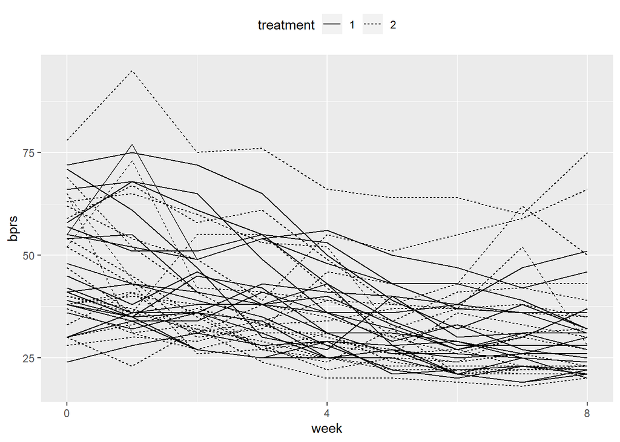

```r
ggplot(BPRSL, aes(x = week, y = bprs, group = interaction(subject, treatment))) +
  geom_line(aes(linetype = treatment)) +
  scale_x_continuous(name = "week", breaks = seq(0, 8, 4)) +
  scale_y_continuous(name = "bprs") +
  theme(legend.position = "top")
```

This is the same plot as we saw before and it shows the change in bprs in subjects of the two treatment groups throughout the 8 weeks of the study.

Creating a vector of the fitted values and adding a new column

```r
Fitted <- fitted(BPRS_ref2)
BPRSL <- BPRSL %>%
  mutate(Fitted)
```

Drawing the plot of BPRSL with fitted values

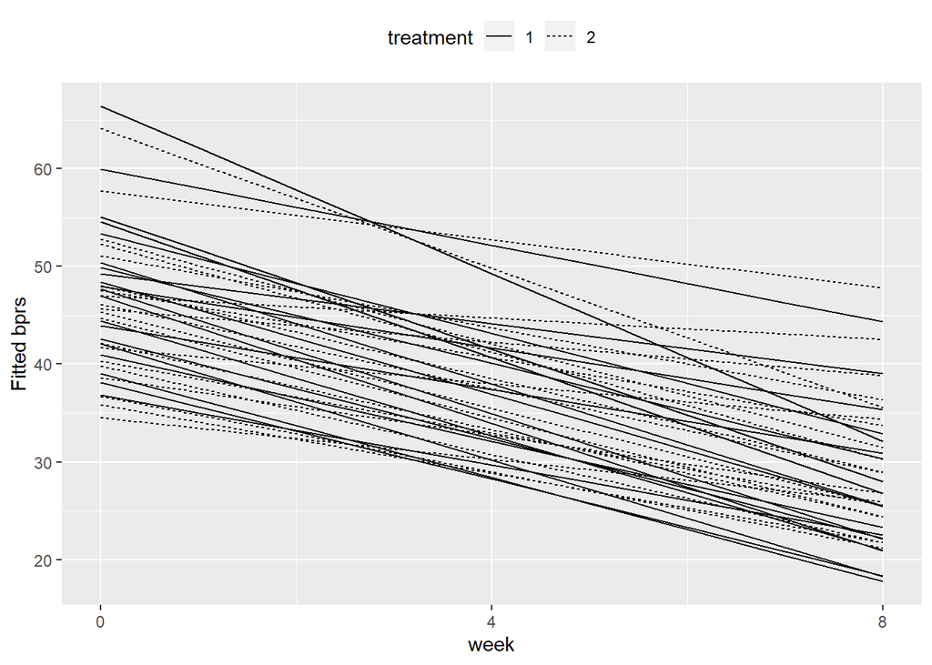

```r
ggplot(BPRSL, aes(x = week, y = Fitted, group = interaction(subject, treatment))) +
  geom_line(aes(linetype = treatment)) +
  scale_x_continuous(name = "week", breaks = seq(0, 8, 4)) +
  scale_y_continuous(name = "Fitted bprs") +
  theme(legend.position = "top")
```

This plot, which is based on fitted (predicted) bprs values, suggests that the change in bprs scores of subjects in two treatment groups would be like as in the graph. However, we saw that this linear change does not happen in real setting and there is kind of a fluctutation in bprs scores throughout the 8 weeks of the study.